# Research guide: CBSA-year frame

Population (BEA, midyear)

| ROWS | DISTINCT |
| --- | --- |
| 23,125 | 21,743 (94.0%) |

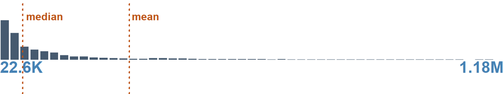

**PREVIEW**:

```
22316 · 37008 · 37852 · 38506 · 45216 · 46085 · 21209 · 21763 · 22578 · 24593 · 25094 · 25263
25482 · 25677 · 25774 · 25786 · 28010 · 29171 · 29990 · 30668 · 30777 · 32248 · 33061 · 33221
```

**STATS**:

| MIN | Q05 | Q25 | Q50 | MEAN | Q75 | Q95 | MAX |
| --- | --- | --- | --- | --- | --- | --- | --- |
| 9,415 | 22,827 | 40,763 | 74,704 | 318,583 | 183,462 | 1,153,534 | 20,074,970 |

number

Earnings by place of work

`earn_total`

Earnings by place of work

| ROWS | DISTINCT |
| --- | --- |
| 23,125 | 23,060 (99.7%) |

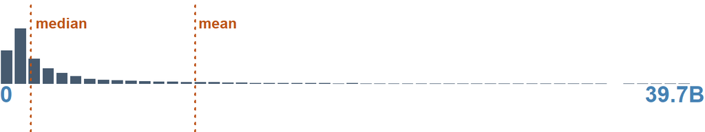

**PREVIEW**:

```
258470000 · 276281000 · 341500000 · 380909000 · 395630000 · 407705000 · 438817000 · 456330000
491182000 · 502472000 · 524309000 · 565743000 · 643070000 · 644783000 · 648393000 · 675130000
```

**STATS**:

| MIN | Q05 | Q25 | Q50 | MEAN | Q75 | Q95 | MAX |
| --- | --- | --- | --- | --- | --- | --- | --- |
| 91,603,000 | 458,054,800 | 868,597,000 | 1,743,228,000 | 11,012,831,224 | 4,861,797,000 | 39,437,937,000 | 1.390171e+12 |

number · measurement

Wages and salaries

`wages_total`

Wages and salaries

| ROWS | DISTINCT |
| --- | --- |
| 23,125 | 23,038 (99.6%) |

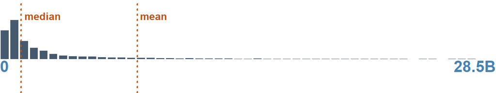

**PREVIEW**:

```
218843000 · 225358000 · 254386000 · 254743000 · 277466000 · 279818000 · 298865000 · 325091000
337688000 · 342564000 · 346388000 · 356292000 · 373790000 · 387746000 · 389685000 · 390231000
```

**STATS**:

| MIN | Q05 | Q25 | Q50 | MEAN | Q75 | Q95 | MAX |
| --- | --- | --- | --- | --- | --- | --- | --- |
| 63,205,000 | 301,850,800 | 588,964,000 | 1,209,410,000 | 7,904,980,140 | 3,398,864,000 | 28,272,139,600 | 1.018741e+12 |

number

Earnings: government and government enterprises

`gov_earn_total`

Earnings: government and government enterprises

| ROWS | DISTINCT |
| --- | --- |
| 23,125 | 22,850 (98.8%) |

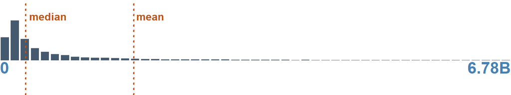

**PREVIEW**:

```
131175000 · 146340000 · 151551000 · 441908000 · 55402000 · 56751000 · 58036000 · 62410000
67737000 · 68579000 · 69538000 · 70658000 · 70843000 · 73674000 · 74572000 · 75876000 · 77569000
```

**STATS**:

| MIN | Q05 | Q25 | Q50 | MEAN | Q75 | Q95 | MAX |
| --- | --- | --- | --- | --- | --- | --- | --- |
| 28,547,000 | 81,269,000 | 158,990,000 | 340,398,000 | 1,774,920,901 | 1,002,318,000 | 6,730,978,400 | 173,644,761,000 |

number

Earnings: federal civilian government

`gov_earn_federal_civ`

Earnings: federal civilian government

| ROWS | DISTINCT |
| --- | --- |
| 23,125 | 20,071 (86.8%) |

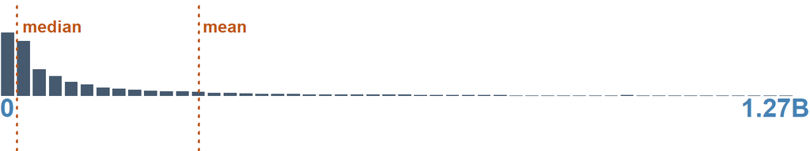

**PREVIEW**:

```
6060000 · 7951000 · 4392000 · 5815000 · 6100000 · 6191000 · 6336000 · 6404000 · 6438000
6558000 · 6878000 · 7025000 · 7167000 · 7487000 · 8011000 · 8113000 · 8508000 · 9476000
```

**STATS**:

| MIN | Q05 | Q25 | Q50 | MEAN | Q75 | Q95 | MAX |
| --- | --- | --- | --- | --- | --- | --- | --- |
| 1,104,000 | 4,789,000 | 10,244,000 | 26,649,000 | 311,724,352 | 129,259,000 | 1,250,405,000 | 79,890,417,000 |

number

Earnings: military

`gov_earn_military`

Earnings: military

| ROWS | DISTINCT |
| --- | --- |
| 23,125 | 16,251 (70.3%) |

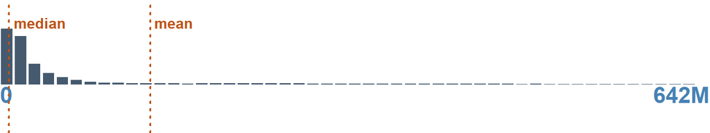

**PREVIEW**:

```
2736000 · 3184000 · 3727000 · 4889000 · 5573000 · 2021000 · 2023000 · 2291000 · 2539000
2863000 · 2912000 · 3127000 · 3224000 · 3242000 · 3621000 · 3659000 · 3819000 · 3941000
```

**STATS**:

| MIN | Q05 | Q25 | Q50 | MEAN | Q75 | Q95 | MAX |
| --- | --- | --- | --- | --- | --- | --- | --- |
| 374,000 | 1,890,000 | 4,090,000 | 8,183,000 | 136,183,535 | 29,309,000 | 632,052,400 | 10,701,098,000 |

number · measurement

Earnings: state and local government

`gov_earn_sl`

Earnings: state and local government

| ROWS | DISTINCT |
| --- | --- |
| 23,125 | 22,808 (98.6%) |

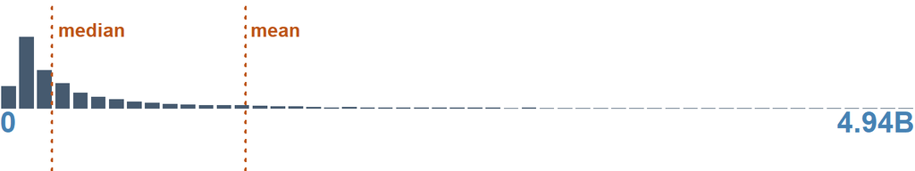

**PREVIEW**:

```
62578000 · 83475000 · 86033000 · 143608000 · 168966000 · 483027000 · 42364000 · 47153000
47326000 · 47699000 · 48362000 · 54416000 · 54465000 · 57687000 · 58026000 · 61181000 · 63029000
```

**STATS**:

| MIN | Q05 | Q25 | Q50 | MEAN | Q75 | Q95 | MAX |
| --- | --- | --- | --- | --- | --- | --- | --- |
| 25,882,000 | 70,145,800 | 135,838,000 | 279,743,000 | 1,327,013,014 | 750,337,000 | 4,912,115,400 | 155,877,644,000 |

number

Total employment

`emp_total`

Total employment (jobs)

| ROWS | DISTINCT | MISSING/NA |
| --- | --- | --- |
| 23,125 | 19,201 (83.0%) | 1,850 (8.0%) |

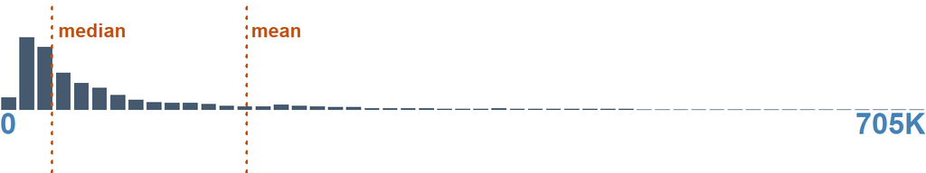

**PREVIEW**:

```
22298 · 12845 · 14195 · 14665 · 16067 · 16172 · 17475 · 18351 · 18622 · 18993 · 19152 · 19212
20931 · 21728 · 21814 · 22061 · 23291 · 25133 · 25435 · 26937 · 28327 · 28964 · 29587 · 46499
```

**STATS**:

| MIN | Q05 | Q25 | Q50 | MEAN | Q75 | Q95 | MAX |
| --- | --- | --- | --- | --- | --- | --- | --- |
| 4,143 | 12,490.7 | 21,922.5 | 39,508 | 187,949.2 | 104,256 | 704,350.9 | 13,374,807 |

number

Employment: government and government enterprises

`gov_emp_total`

Employment: government and government enterprises

| ROWS | DISTINCT | MISSING/NA |
| --- | --- | --- |
| 23,125 | 13,350 (57.7%) | 1,850 (8.0%) |

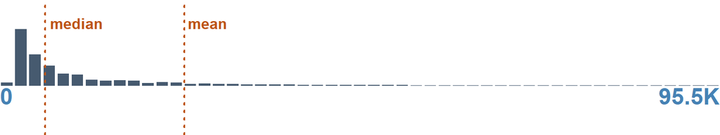

**PREVIEW**:

```
2731 · 3234 · 2146 · 2191 · 2621 · 2686 · 3223 · 1604 · 2068 · 2083 · 2087 · 2113 · 2149 · 2169
2253 · 2259 · 2267 · 2280 · 2317 · 2319 · 2393 · 2426 · 2496 · 2499 · 2533 · 2641 · 2939 · 3056
```

**STATS**:

| MIN | Q05 | Q25 | Q50 | MEAN | Q75 | Q95 | MAX |
| --- | --- | --- | --- | --- | --- | --- | --- |
| 713 | 1,741 | 3,102.5 | 6,000 | 24,451.18 | 16,651.5 | 95,335.51 | 1,329,976 |

number

Employment: state and local government

`gov_emp_sl`

Employment: state and local government

| ROWS | DISTINCT | MISSING/NA |
| --- | --- | --- |
| 23,125 | 12,568 (54.3%) | 1,850 (8.0%) |

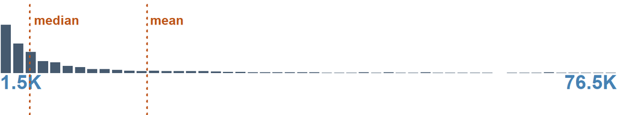

**PREVIEW**:

```
2508 · 1532 · 1874 · 2264 · 2280 · 2667 · 2712 · 2772 · 2801 · 1530 · 1581 · 1658 · 1698 · 1884
1927 · 1960 · 1985 · 2013 · 2066 · 2136 · 2171 · 2277 · 2317 · 2651 · 2659 · 2784 · 1379 · 1589
```

**STATS**:

| MIN | Q05 | Q25 | Q50 | MEAN | Q75 | Q95 | MAX |
| --- | --- | --- | --- | --- | --- | --- | --- |
| 593 | 1,540.7 | 2,709.5 | 5,146 | 19,384.47 | 13,032 | 76,495.3 | 1,177,651 |

number · measurement

Real GDP

`gdp_real`

Real GDP (chained 2017 dollars)

| ROWS | DISTINCT | MISSING/NA |
| --- | --- | --- |
| 23,125 | 22,165 (95.8%) | 925 (4.0%) |

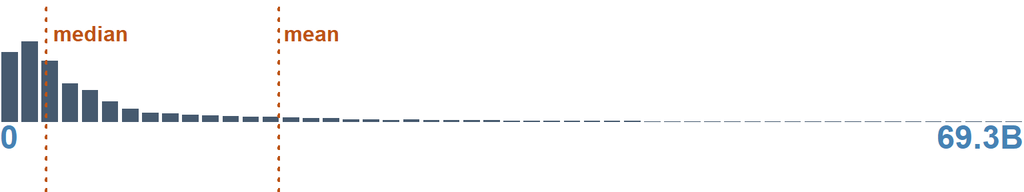

**PREVIEW**:

```
717638000 · 764931000 · 866831000 · 909751000 · 913318000 · 934271000 · 988849000 · 1047702000
1162632000 · 1179189000 · 1179996000 · 1202419000 · 1227184000 · 1232928000 · 1307079000
```

**STATS**:

| MIN | Q05 | Q25 | Q50 | MEAN | Q75 | Q95 | MAX |
| --- | --- | --- | --- | --- | --- | --- | --- |
| 310,619,000 | 907,200,450 | 1,604,815,000 | 3,130,106,500 | 18,873,326,717 | 8,450,336,000 | 68,875,085,650 | 1.945574e+12 |

number · measurement

Current-dollar GDP

`gdp_nominal`

Current-dollar GDP

| ROWS | DISTINCT | MISSING/NA |
| --- | --- | --- |
| 23,125 | 22,177 (95.9%) | 925 (4.0%) |

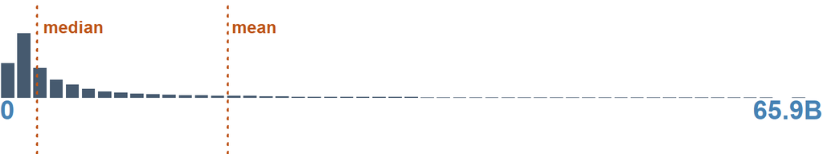

**PREVIEW**:

```
771632000 · 851587000 · 851888000 · 883454000 · 891800000 · 1022126000 · 1037197000 · 1063805000
1174315000 · 1215088000 · 1262332000 · 1270391000 · 1317306000 · 1384245000 · 1390701000
```

**STATS**:

| MIN | Q05 | Q25 | Q50 | MEAN | Q75 | Q95 | MAX |
| --- | --- | --- | --- | --- | --- | --- | --- |
| 286,124,000 | 788,582,100 | 1,503,182,750 | 2,996,605,000 | 18,248,630,969 | 8,230,835,000 | 65,408,656,850 | 2.4425e+12 |

number · measurement

Personal current transfer receipts

`tr_total`

Personal current transfer receipts. Gap-filled: interpolated between observed years; see also tr_total_obs, _lin and _locf.

| ROWS | DISTINCT |
| --- | --- |
| 23,125 | 21,131 (91.4%) |

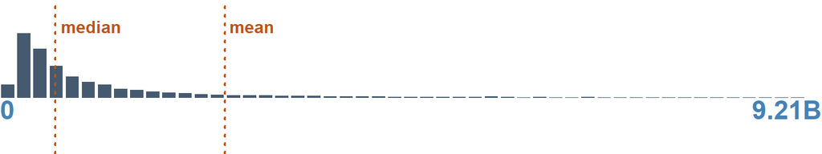

**PREVIEW**:

```
281156000 · 283169000 · 319894000 · 322414000 · 339571000 · 484998000 · 529660000 · 581805000
724156000 · 766849000 · 987559000 · 116532000 · 133616000 · 153506000 · 156437000 · 163259000
```

**STATS**:

| MIN | Q05 | Q25 | Q50 | MEAN | Q75 | Q95 | MAX |
| --- | --- | --- | --- | --- | --- | --- | --- |
| 25,642,000 | 142,025,000 | 321,460,000 | 621,427,000 | 2,523,298,572 | 1,535,606,000 | 9,173,178,800 | 318,831,672,000 |

number · measurement

Transfer receipts of individuals from governments

`tr_gov`

Transfer receipts of individuals from governments. Gap-filled: interpolated between observed years; see also tr_gov_obs, _lin and _locf.

| ROWS | DISTINCT |
| --- | --- |
| 23,125 | 21,135 (91.4%) |

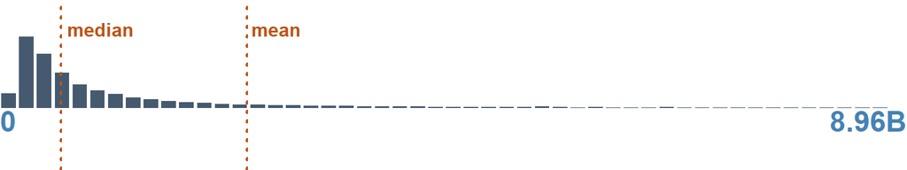

**PREVIEW**:

```
177395000 · 209098000 · 323198000 · 327295000 · 523231000 · 1069592000 · 1117737000 · 1446702000
109963000 · 125753000 · 147302000 · 148315000 · 153529000 · 156171000 · 167530000 · 167621000
```

**STATS**:

| MIN | Q05 | Q25 | Q50 | MEAN | Q75 | Q95 | MAX |
| --- | --- | --- | --- | --- | --- | --- | --- |
| 23,859,000 | 137,246,600 | 312,099,000 | 603,014,000 | 2,442,283,400 | 1,488,173,000 | 8,925,315,200 | 307,417,179,000 |

number

Social Security benefits

`tr_socsec`

Social Security benefits. Gap-filled: interpolated between observed years; see also tr_socsec_obs, _lin and _locf.

| ROWS | DISTINCT |
| --- | --- |
| 23,125 | 20,865 (90.2%) |

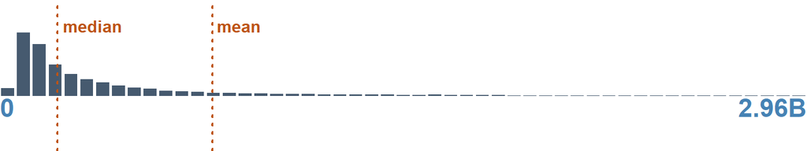

**PREVIEW**:

```
167711000 · 289646000 · 169350000 · 80817000 · 94770000 · 108390000 · 115953000 · 119600000
130645000 · 139106000 · 153894000 · 159277000 · 159988000 · 163036000 · 176034000 · 191769000
```

**STATS**:

| MIN | Q05 | Q25 | Q50 | MEAN | Q75 | Q95 | MAX |
| --- | --- | --- | --- | --- | --- | --- | --- |
| 10,690,000 | 49,461,000 | 108,887,000 | 210,015,000 | 779,083,871 | 507,640,000 | 2,948,856,400 | 64,748,655,000 |

number

Medical benefits

`tr_medical`

Medical benefits (Medicare + Medicaid + military). Gap-filled: interpolated between observed years; see also tr_medical_obs, _lin and _locf.

| ROWS | DISTINCT |
| --- | --- |
| 23,125 | 20,965 (90.7%) |

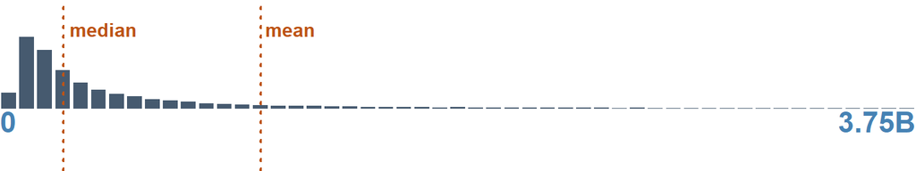

**PREVIEW**:

```
134393000 · 200825000 · 234888000 · 249937000 · 273910000 · 346206000 · 350361000 · 732973000
40028000 · 45514000 · 49534000 · 57473000 · 62075000 · 63821000 · 69651000 · 73197000 · 73490000
```

**STATS**:

| MIN | Q05 | Q25 | Q50 | MEAN | Q75 | Q95 | MAX |
| --- | --- | --- | --- | --- | --- | --- | --- |
| 8,026,000 | 55,953,400 | 133,097,000 | 259,501,000 | 1,065,912,176 | 631,780,000 | 3,728,881,200 | 137,649,426,000 |

number · measurement

Medicare benefits

`tr_medicare`

Medicare benefits. Gap-filled: interpolated between observed years; see also tr_medicare_obs, _lin and _locf.

| ROWS | DISTINCT |
| --- | --- |
| 23,125 | 20,682 (89.4%) |

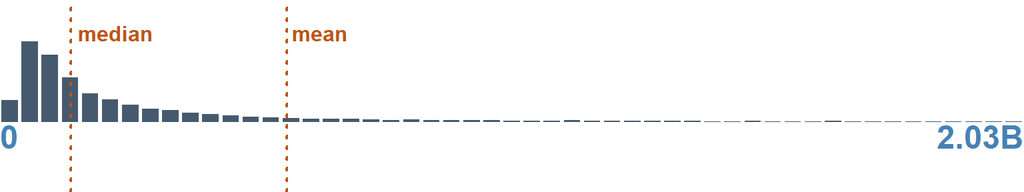

**PREVIEW**:

```
96872000 · 107714000 · 124164000 · 156255000 · 44722000 · 54552000 · 55065000 · 57783000
74761000 · 78784000 · 80295000 · 80783000 · 82848000 · 102751000 · 104152000 · 111175000
```

**STATS**:

| MIN | Q05 | Q25 | Q50 | MEAN | Q75 | Q95 | MAX |
| --- | --- | --- | --- | --- | --- | --- | --- |
| 5,771,000 | 29,004,800 | 71,671,000 | 140,210,000 | 568,356,177 | 346,482,000 | 2,019,516,800 | 57,881,730,000 |

number

Public assistance medical care

`tr_medicaid`

Public assistance medical care (mostly Medicaid). Gap-filled: interpolated between observed years; see also tr_medicaid_obs, _lin and _locf.

| ROWS | DISTINCT |
| --- | --- |
| 23,125 | 20,636 (89.2%) |

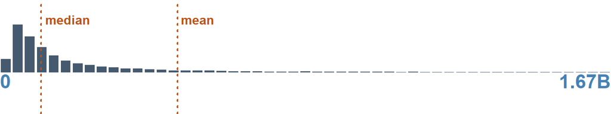

**PREVIEW**:

```
151890000 · 27281000 · 27728000 · 30406000 · 35466000 · 42364000 · 49998000 · 54989000
57843000 · 57855000 · 61625000 · 63665000 · 65230000 · 66583000 · 67466000 · 68092000 · 72572000
```

**STATS**:

| MIN | Q05 | Q25 | Q50 | MEAN | Q75 | Q95 | MAX |
| --- | --- | --- | --- | --- | --- | --- | --- |
| 1,752,000 | 22,682,000 | 56,304,000 | 111,979,000 | 484,879,907 | 272,197,000 | 1,656,168,000 | 79,659,184,000 |

number

Income maintenance

`tr_income_maint`

Income maintenance (SSI, EITC, SNAP, other). Gap-filled: interpolated between observed years; see also tr_income_maint_obs, _lin and _locf.

| ROWS | DISTINCT |
| --- | --- |
| 23,125 | 19,980 (86.4%) |

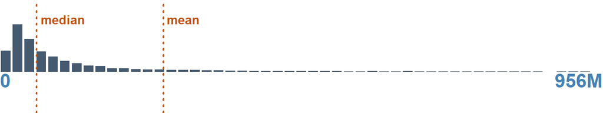

**PREVIEW**:

```
28036000 · 41738000 · 63124000 · 10851000 · 29745000 · 44467000 · 59854000 · 115219000 · 9920000
10410000 · 12960000 · 16102000 · 19246000 · 22599000 · 23167000 · 23718000 · 23834000 · 25178000
```

**STATS**:

| MIN | Q05 | Q25 | Q50 | MEAN | Q75 | Q95 | MAX |
| --- | --- | --- | --- | --- | --- | --- | --- |
| 898,000 | 10,657,800 | 28,036,000 | 58,024,000 | 259,367,487 | 145,267,000 | 947,782,200 | 30,975,025,000 |

number

SNAP benefits

`tr_snap`

SNAP benefits. Gap-filled: interpolated between observed years; see also tr_snap_obs, _lin and _locf.

| ROWS | DISTINCT | ZERO |
| --- | --- | --- |
| 23,125 | 16,921 (73.2%) | 1 (0.0%) |

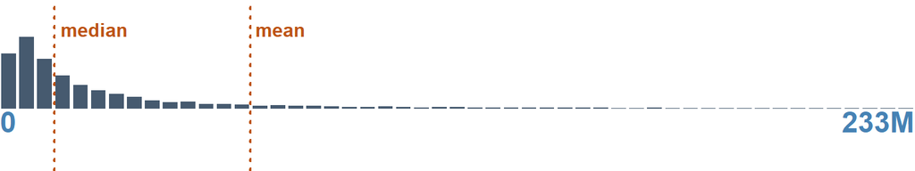

**PREVIEW**:

```
3943000 · 7161000 · 9924000 · 10172000 · 2425000 · 2527000 · 2828000 · 3286000 · 3352000
3437000 · 4474000 · 4579000 · 5099000 · 5269000 · 5842000 · 8198000 · 9037000 · 9344000
```

**STATS**:

| MIN | Q05 | Q25 | Q50 | MEAN | Q75 | Q95 | MAX |
| --- | --- | --- | --- | --- | --- | --- | --- |
| 0 | 1,753,200 | 5,899,000 | 13,935,000 | 63,868,915 | 36,526,000 | 230,408,200 | 9,021,466,000 |

number

Unemployment insurance compensation

`tr_unemp`

Unemployment insurance compensation. Gap-filled: interpolated between observed years; see also tr_unemp_obs, _lin and _locf.

| ROWS | DISTINCT |
| --- | --- |
| 23,125 | 16,362 (70.8%) |

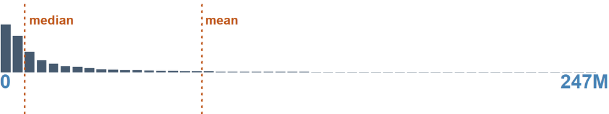

**PREVIEW**:

```
1765000 · 914000 · 3884000 · 5181000 · 2402000 · 795000 · 1123000 · 1280000 · 2239000 · 2425000
3476000 · 4141000 · 644000 · 650000 · 708000 · 788000 · 948000 · 997000 · 1027000 · 1099000
```

**STATS**:

| MIN | Q05 | Q25 | Q50 | MEAN | Q75 | Q95 | MAX |
| --- | --- | --- | --- | --- | --- | --- | --- |
| 69,000 | 1,256,400 | 4,027,000 | 10,121,000 | 81,930,323 | 31,636,000 | 243,449,800 | 53,355,534,000 |

number · measurement

Veterans' benefits

`tr_veterans`

Veterans' benefits. Gap-filled: interpolated between observed years; see also tr_veterans_obs, _lin and _locf.

| ROWS | DISTINCT |
| --- | --- |
| 23,125 | 18,021 (77.9%) |

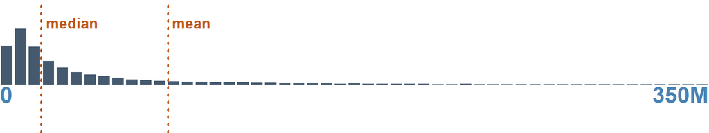

**PREVIEW**:

```
3306000 · 7029000 · 9659000 · 11344000 · 16165000 · 2322000 · 2356000 · 3233000 · 3600000
4111000 · 4186000 · 5226000 · 8461000 · 10020000 · 10135000 · 11525000 · 11622000 · 11667000
```

**STATS**:

| MIN | Q05 | Q25 | Q50 | MEAN | Q75 | Q95 | MAX |
| --- | --- | --- | --- | --- | --- | --- | --- |
| 254,000 | 2,988,000 | 8,971,000 | 20,477,000 | 83,281,001 | 56,253,000 | 346,779,000 | 3,667,539,000 |

number

Education and training assistance

`tr_education`

Education and training assistance. Gap-filled: interpolated between observed years; see also tr_education_obs, _lin and _locf.

| ROWS | DISTINCT |
| --- | --- |
| 23,125 | 16,829 (72.8%) |

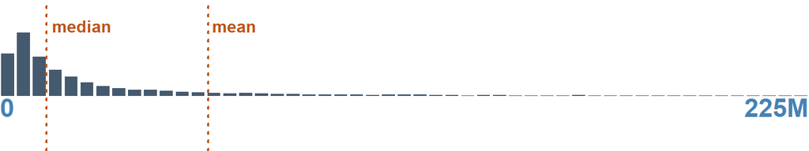

**PREVIEW**:

```
4421000 · 2978000 · 4514000 · 6381000 · 6467000 · 6530000 · 7051000 · 7506000 · 7820000
12585000 · 12935000 · 1689000 · 1910000 · 1969000 · 2309000 · 2577000 · 2639000 · 2770000
```

**STATS**:

| MIN | Q05 | Q25 | Q50 | MEAN | Q75 | Q95 | MAX |
| --- | --- | --- | --- | --- | --- | --- | --- |
| 252,000 | 1,970,000 | 5,611,000 | 12,890,000 | 57,891,642 | 35,306,000 | 222,326,200 | 4,627,597,000 |

number · measurement

Transfer receipts of nonprofit institutions

`tr_nonprofit`

Transfer receipts of nonprofit institutions (descriptive only). Gap-filled: interpolated between observed years; see also tr_nonprofit_obs, _lin and _locf.

| ROWS | DISTINCT |
| --- | --- |
| 23,125 | 15,451 (66.8%) |

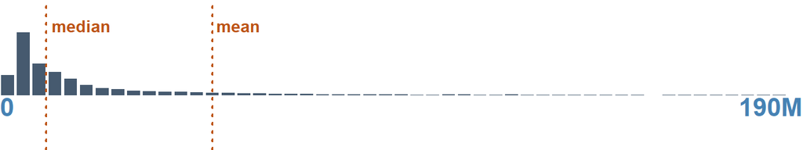

**PREVIEW**:

```
11814000 · 4807000 · 4339000 · 5369000 · 2945000 · 3789000 · 3948000 · 4052000 · 4370000
4652000 · 4727000 · 4792000 · 4812000 · 5276000 · 6774000 · 7426000 · 12540000 · 2906000
```

**STATS**:

| MIN | Q05 | Q25 | Q50 | MEAN | Q75 | Q95 | MAX |
| --- | --- | --- | --- | --- | --- | --- | --- |
| 751,000 | 2,653,200 | 5,138,000 | 10,895,000 | 50,229,505 | 27,934,000 | 188,781,200 | 13,251,110,000 |

number

Total presidential votes cast

`votes_total`

Total presidential votes cast (all candidates)

| ROWS | DISTINCT | MISSING/NA |
| --- | --- | --- |
| 23,125 | 6,222 (26.9%) | 16,650 (72.0%) |

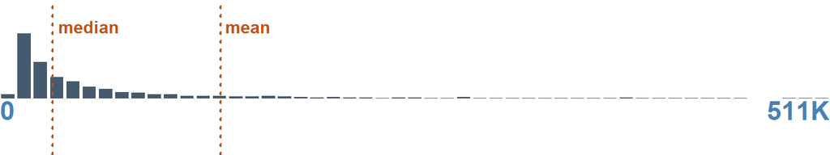

**PREVIEW**:

```
9118 · 9558 · 10910 · 11960 · 15049 · 16323 · 16651 · 17822 · 19121 · 5289 · 6772 · 7312 · 7718
8258 · 8362 · 8766 · 8837 · 8951 · 9034 · 9337 · 9369 · 9542 · 9553 · 9838 · 10119 · 10159
```

**STATS**:

| MIN | Q05 | Q25 | Q50 | MEAN | Q75 | Q95 | MAX |
| --- | --- | --- | --- | --- | --- | --- | --- |
| 2,616 | 9,238.1 | 16,967 | 32,513 | 135,988.2 | 81,446 | 510,232.8 | 8,538,916 |

number

Democratic presidential votes

`votes_dem`

Democratic presidential votes

| ROWS | DISTINCT | MISSING/NA |
| --- | --- | --- |
| 23,125 | 5,920 (25.6%) | 16,650 (72.0%) |

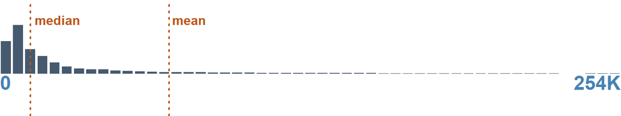

**PREVIEW**:

```
4002 · 2692 · 3536 · 3973 · 5208 · 7650 · 8322 · 15489 · 2782 · 2804 · 2881 · 3158 · 3171 · 3195
3218 · 3297 · 3301 · 3340 · 3385 · 3438 · 3475 · 3494 · 3830 · 4210 · 4213 · 4625 · 4736 · 4916
```

**STATS**:

| MIN | Q05 | Q25 | Q50 | MEAN | Q75 | Q95 | MAX |
| --- | --- | --- | --- | --- | --- | --- | --- |
| 677 | 2,598.1 | 5,688 | 12,492 | 69,089.92 | 35,209 | 251,738.7 | 5,411,980 |

number

Republican presidential votes

`votes_rep`

Republican presidential votes

| ROWS | DISTINCT | MISSING/NA |
| --- | --- | --- |
| 23,125 | 6,086 (26.3%) | 16,650 (72.0%) |

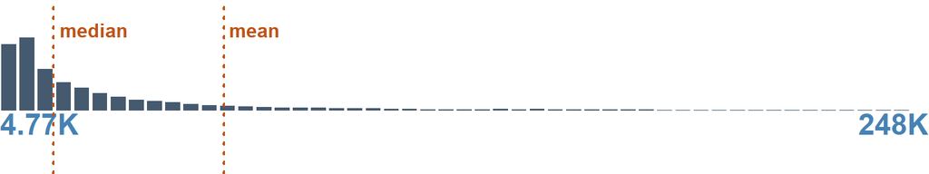

**PREVIEW**:

```
4526 · 6984 · 7332 · 7483 · 7699 · 7936 · 8312 · 8346 · 8545 · 8945 · 9545 · 9680 · 9811 · 9900
10056 · 10176 · 10566 · 11083 · 13606 · 14182 · 30028 · 31580 · 40403 · 1547 · 2171 · 3285
```

**STATS**:

| MIN | Q05 | Q25 | Q50 | MEAN | Q75 | Q95 | MAX |
| --- | --- | --- | --- | --- | --- | --- | --- |
| 919 | 5,203.2 | 10,288 | 18,730 | 63,535.3 | 44,511.5 | 243,794.5 | 3,377,483 |

number

QCEW federal government employment

`qcew_fgov_emp`

QCEW federal government employment (annual average, place of work)

| ROWS | DISTINCT |
| --- | --- |
| 23,125 | 5,820 (25.2%) |

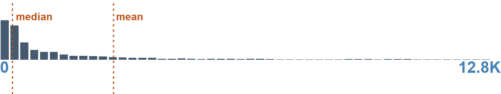

**PREVIEW**:

```
114 · 85 · 103 · 101 · 104 · 96 · 82 · 88 · 106 · 84 · 94 · 102 · 107 · 74 · 93 · 97 · 89 · 117
76 · 100 · 108 · 110 · 124 · 79 · 83 · 116 · 122 · 95 · 105 · 98 · 121 · 140 · 86 · 72 · 75 · 87
```

**STATS**:

| MIN | Q05 | Q25 | Q50 | MEAN | Q75 | Q95 | MAX |
| --- | --- | --- | --- | --- | --- | --- | --- |
| 13 | 69 | 137 | 321 | 2,901.58 | 1,465 | 12,580 | 382,691 |

number · measurement

QCEW state government employment

`qcew_sgov_emp`

QCEW state government employment

| ROWS | DISTINCT |
| --- | --- |
| 23,125 | 9,795 (42.4%) |

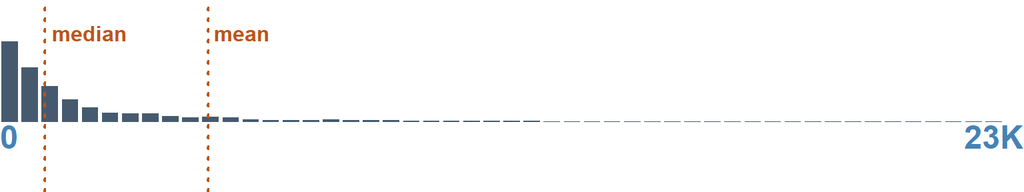

**PREVIEW**:

```
48 · 103 · 106 · 59 · 96 · 104 · 51 · 108 · 73 · 143 · 54 · 61 · 64 · 67 · 68 · 81 · 112 · 132
209 · 66 · 124 · 129 · 50 · 63 · 95 · 97 · 99 · 247 · 323 · 56 · 87 · 100 · 110 · 141 · 46 · 47
```

**STATS**:

| MIN | Q05 | Q25 | Q50 | MEAN | Q75 | Q95 | MAX |
| --- | --- | --- | --- | --- | --- | --- | --- |
| 7 | 87 | 343 | 1,007 | 4,686.88 | 3,159 | 22,593.8 | 147,236.2 |

number · measurement

QCEW local government employment

`qcew_lgov_emp`

QCEW local government employment (incl. public schools and hospitals)

| ROWS | DISTINCT |
| --- | --- |
| 23,125 | 13,101 (56.7%) |

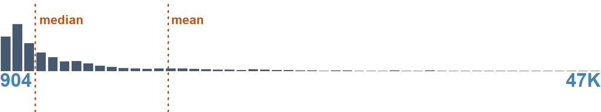

**PREVIEW**:

```
1884 · 1395 · 1430 · 1437 · 1879 · 1267 · 1360 · 1471 · 1591 · 1698 · 1744 · 1868 · 1979 · 2046
1111 · 1297 · 1408 · 1420 · 1440 · 1449 · 1534 · 1557 · 1559 · 1706 · 1970 · 2084 · 2160 · 2162
```

**STATS**:

| MIN | Q05 | Q25 | Q50 | MEAN | Q75 | Q95 | MAX |
| --- | --- | --- | --- | --- | --- | --- | --- |
| 473 | 1,194 | 2,046 | 3,627 | 13,828.24 | 8,398 | 46,381.6 | 990,038 |

number

QCEW federal government total annual wages

`qcew_fgov_wages`

QCEW federal government total annual wages ($)

| ROWS | DISTINCT |
| --- | --- |
| 23,125 | 23,123 (100.0%) |

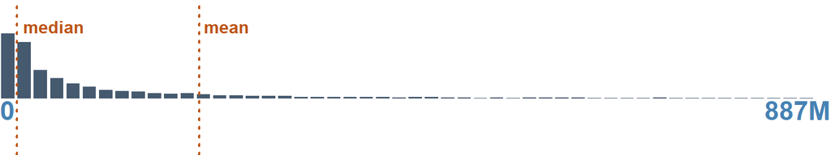

**PREVIEW**:

```
5232890 · 16943585 · 727914 · 756950 · 858424 · 880685 · 889006 · 924694 · 926115 · 935991
955375 · 976755 · 996076 · 996667 · 997809 · 1009506 · 1028478 · 1032149 · 1038062 · 1050877
```

**STATS**:

| MIN | Q05 | Q25 | Q50 | MEAN | Q75 | Q95 | MAX |
| --- | --- | --- | --- | --- | --- | --- | --- |
| 727,914 | 3,297,552 | 7,002,381 | 18,421,765 | 213,043,383 | 90,157,733 | 873,314,749 | 51,837,248,503 |

number · measurement

QCEW state government wages

`qcew_sgov_wages`

QCEW state government wages ($)

| ROWS | DISTINCT |
| --- | --- |
| 23,125 | 23,123 (100.0%) |

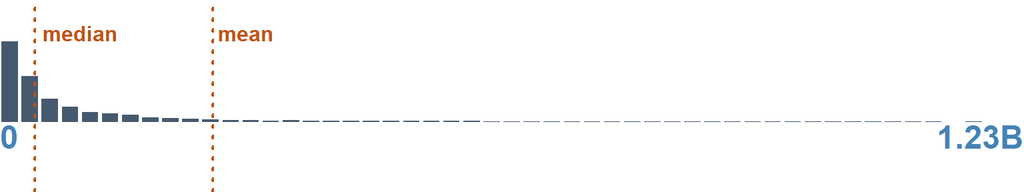

**PREVIEW**:

```
6786152 · 71698762 · 300082 · 514164 · 537812 · 563602 · 596597 · 611140 · 627023 · 639933
652291 · 654994 · 686328 · 694171 · 696265 · 700758 · 708590 · 717704 · 723482 · 734473 · 741597
```

**STATS**:

| MIN | Q05 | Q25 | Q50 | MEAN | Q75 | Q95 | MAX |
| --- | --- | --- | --- | --- | --- | --- | --- |
| 300,082 | 3,556,726 | 14,446,771 | 42,182,729 | 254,996,798 | 142,201,925 | 1,205,546,071 | 16,483,755,442 |

number · measurement

QCEW local government wages

`qcew_lgov_wages`

QCEW local government wages ($)

| ROWS | DISTINCT |
| --- | --- |
| 23,125 | 23,125 (100.0%) |

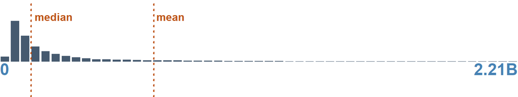

**PREVIEW**:

```
9800827 · 10398111 · 10864659 · 12278331 · 12588847 · 12878000 · 13024917 · 13170718 · 13255071
13354151 · 13784689 · 14273973 · 14554383 · 14798824.36 · 15440788 · 16533888.693 · 16631243
```

**STATS**:

| MIN | Q05 | Q25 | Q50 | MEAN | Q75 | Q95 | MAX |
| --- | --- | --- | --- | --- | --- | --- | --- |
| 9,800,827 | 37,349,979 | 70,892,382 | 133,529,131 | 656,773,879 | 335,259,386 | 2,207,064,329 | 87,190,531,845 |

number · measurement

`qcew_sgov_imputed`

Count of member counties flagged (county flags summed; fractional where a county was split by population). County flag: 1 = suppressed county cell, imputed as state total minus disclosed counties, allocated by population: state

| ROWS | DISTINCT | ZERO |
| --- | --- | --- |
| 23,125 | 20 (0.1%) | 19,863 (85.9%) |

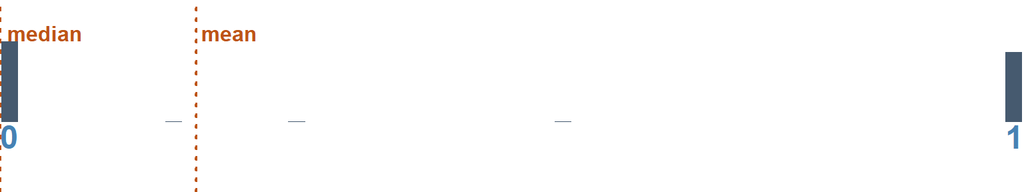

**PREVIEW**:

```
0 · 1 · 2 · 3 · 5 · 7 · 8 · 4 · 0.161 · 0.294 · 0.546 · 0.21 · 0.79 · 6 · 11 · 0.795 · 0.995 · 9
10 · 12
```

**STATS**:

| MIN | Q05 | Q25 | Q50 | MEAN | Q75 | Q95 | MAX |
| --- | --- | --- | --- | --- | --- | --- | --- |
| 0 | 0 | 0 | 0 | 0.19 | 0 | 1 | 12 |

number

`qcew_lgov_imputed`

Count of member counties flagged (county flags summed; fractional where a county was split by population). County flag: 1 = suppressed county cell, imputed as state total minus disclosed counties, allocated by population: local

| ROWS | DISTINCT | ZERO |
| --- | --- | --- |
| 23,125 | 21 (0.1%) | 20,091 (86.9%) |

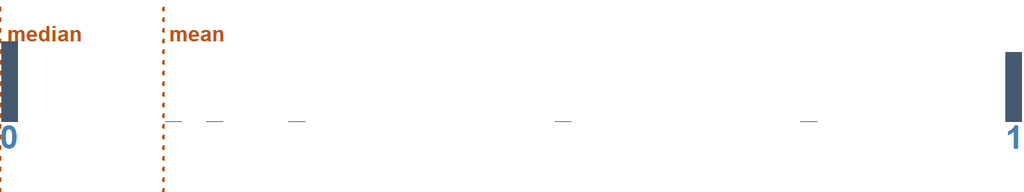

**PREVIEW**:

```
0 · 1 · 2 · 3 · 5 · 4 · 0.161 · 0.294 · 0.546 · 0.995 · 6 · 0.005 · 0.21 · 0.79 · 8 · 0.795 · 7
11 · 9 · 10 · 12
```

**STATS**:

| MIN | Q05 | Q25 | Q50 | MEAN | Q75 | Q95 | MAX |
| --- | --- | --- | --- | --- | --- | --- | --- |
| 0 | 0 | 0 | 0 | 0.16 | 0 | 1 | 12 |

number

ACS civilian employed residents 16+

`acs_cow_den`

ACS civilian employed residents 16+ (B24080 universe)

| ROWS | DISTINCT | MISSING/NA |
| --- | --- | --- |
| 23,125 | 13,589 (58.8%) | 8,325 (36.0%) |

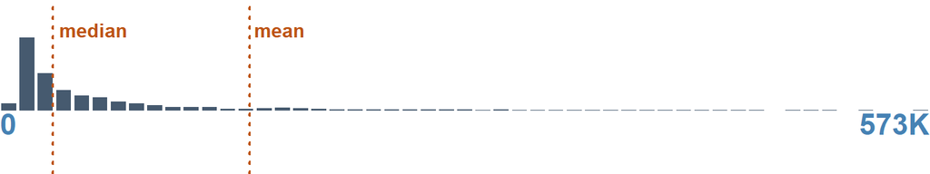

**PREVIEW**:

```
15503 · 11043 · 15305 · 17199 · 17310 · 18616 · 18709 · 19254 · 19526 · 22320 · 8406 · 8849
9958 · 10431 · 10523 · 10632 · 10722 · 10744 · 10794 · 10800 · 11024 · 11144 · 11449 · 12227
```

**STATS**:

| MIN | Q05 | Q25 | Q50 | MEAN | Q75 | Q95 | MAX |
| --- | --- | --- | --- | --- | --- | --- | --- |
| 4,001 | 10,143.8 | 18,259 | 32,571.5 | 153,850.1 | 86,642 | 571,819.8 | 9,784,142 |

number

ACS residents working for private not-for-profits

`acs_cow_npo`

ACS residents working for private not-for-profits

| ROWS | DISTINCT | MISSING/NA |
| --- | --- | --- |
| 23,125 | 8,164 (35.3%) | 8,325 (36.0%) |

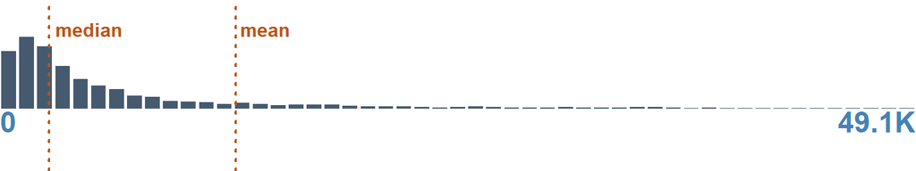

**PREVIEW**:

```
1163 · 683 · 913 · 1235 · 704 · 830 · 866 · 1071 · 1074 · 1101 · 1207 · 1214 · 1329 · 1542 · 730
732 · 735 · 766 · 864 · 876 · 925 · 930 · 983 · 1121 · 1152 · 1180 · 1261 · 1328 · 1381 · 1411
```

**STATS**:

| MIN | Q05 | Q25 | Q50 | MEAN | Q75 | Q95 | MAX |
| --- | --- | --- | --- | --- | --- | --- | --- |
| 53 | 582 | 1,291.75 | 2,636.5 | 12,633.08 | 7,118.25 | 48,687.55 | 966,820 |

number

ACS residents working for local government

`acs_cow_lgov`

ACS residents working for local government

| ROWS | DISTINCT | MISSING/NA |
| --- | --- | --- |
| 23,125 | 7,734 (33.4%) | 8,325 (36.0%) |

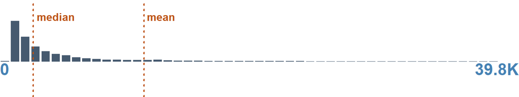

**PREVIEW**:

```
1450 · 998 · 1013 · 1100 · 1132 · 1154 · 1227 · 1278 · 1414 · 1456 · 1505 · 828 · 832 · 886
933 · 1072 · 1090 · 1191 · 1194 · 1210 · 1284 · 1312 · 1333 · 1482 · 1625 · 768 · 884 · 899
```

**STATS**:

| MIN | Q05 | Q25 | Q50 | MEAN | Q75 | Q95 | MAX |
| --- | --- | --- | --- | --- | --- | --- | --- |
| 278 | 768 | 1,369 | 2,543 | 11,052.81 | 6,242 | 39,763.85 | 925,583 |

number

ACS residents working for state government

`acs_cow_sgov`

ACS residents working for state government

| ROWS | DISTINCT | MISSING/NA |
| --- | --- | --- |
| 23,125 | 7,149 (30.9%) | 8,325 (36.0%) |

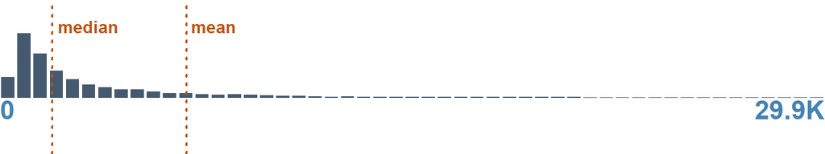

**PREVIEW**:

```
845 · 654 · 870 · 1724 · 457 · 561 · 598 · 601 · 778 · 322 · 461 · 505 · 584 · 644 · 675 · 696
980 · 1006 · 311 · 413 · 515 · 552 · 575 · 576 · 577 · 589 · 599 · 606 · 611 · 639 · 682 · 702
```

**STATS**:

| MIN | Q05 | Q25 | Q50 | MEAN | Q75 | Q95 | MAX |
| --- | --- | --- | --- | --- | --- | --- | --- |
| 25 | 397.95 | 918 | 1,889 | 6,767.67 | 5,060 | 29,688.5 | 317,411 |

number

ACS residents working for federal government

`acs_cow_fgov`

ACS residents working for federal government

| ROWS | DISTINCT | MISSING/NA |
| --- | --- | --- |
| 23,125 | 5,070 (21.9%) | 8,325 (36.0%) |

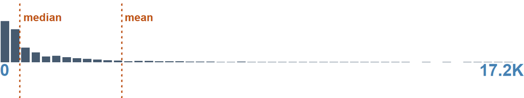

**PREVIEW**:

```
199 · 212 · 191 · 219 · 148 · 165 · 197 · 225 · 182 · 183 · 205 · 214 · 296 · 115 · 184 · 208
213 · 300 · 322 · 158 · 192 · 203 · 211 · 220 · 238 · 250 · 272 · 279 · 145 · 149 · 169 · 170
```

**STATS**:

| MIN | Q05 | Q25 | Q50 | MEAN | Q75 | Q95 | MAX |
| --- | --- | --- | --- | --- | --- | --- | --- |
| 8 | 121 | 285.75 | 651 | 4,004.09 | 2,200 | 16,953.7 | 468,214 |

number · measurement

Local current operations, excl. utilities and liquor stores

`cog_curop`

Local current operations, excl. utilities and liquor stores (E codes). Gap-filled: interpolated between observed years; see also cog_curop_obs, _lin and _locf.

| ROWS | DISTINCT | MISSING/NA |
| --- | --- | --- |
| 23,125 | 19,337 (83.6%) | 1,865 (8.1%) |

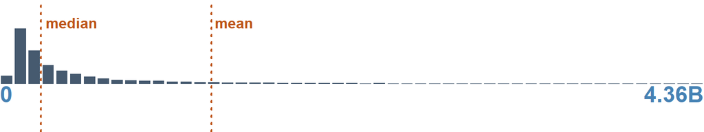

**PREVIEW**:

```
85238000 · 89891000 · 90174000 · 93332000 · 115653000 · 118418000 · 125951000 · 145267000
183020000 · 188036000 · 199765000 · 208309000 · 262994000 · 37812000 · 44379000 · 56089000
```

**STATS**:

| MIN | Q05 | Q25 | Q50 | MEAN | Q75 | Q95 | MAX |
| --- | --- | --- | --- | --- | --- | --- | --- |
| 20,037,000 | 72,462,830 | 135,720,250 | 254,143,700 | 1,308,926,873 | 657,536,650 | 4,342,634,910 | 181,618,110,000 |

number

Local capital outlay, excl. utilities

`cog_capital`

Local capital outlay, excl. utilities (F+G). Gap-filled: interpolated between observed years; see also cog_capital_obs, _lin and _locf.

| ROWS | DISTINCT | MISSING/NA |
| --- | --- | --- |
| 23,125 | 18,960 (82.0%) | 1,865 (8.1%) |

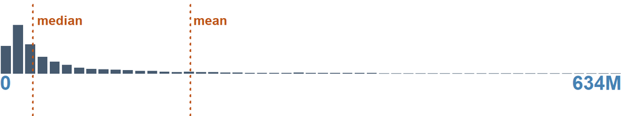

**PREVIEW**:

```
14029000 · 19302000 · 152354000 · 9395000 · 13212000 · 31045000 · 6775000 · 7318000 · 7662000
8338000 · 10399000 · 10850000 · 10919000 · 11215000 · 11371000 · 11522000 · 11865000 · 12538000
```

**STATS**:

| MIN | Q05 | Q25 | Q50 | MEAN | Q75 | Q95 | MAX |
| --- | --- | --- | --- | --- | --- | --- | --- |
| 1,136,000 | 6,538,800 | 15,991,800 | 33,622,600 | 194,073,954 | 95,815,750 | 627,745,080 | 17,719,663,000 |

number · measurement

Local assistance and subsidies

`cog_assist`

Local assistance and subsidies (J). Gap-filled: interpolated between observed years; see also cog_assist_obs, _lin and _locf.

| ROWS | DISTINCT | MISSING/NA | ZERO |
| --- | --- | --- | --- |
| 23,125 | 4,694 (20.3%) | 1,865 (8.1%) | 14,717 (63.6%) |

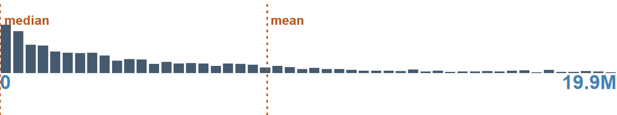

**PREVIEW**:

```
0 · 800 · 400 · 1200 · 1600 · 600 · 1000 · 2000 · 2400 · 200 · 4800 · 1800 · 3000 · 3200 · 4000
8000 · 3600 · 6000 · 6400 · 10400 · 20800 · 4200 · 5600 · 11400 · 16800 · 21000 · 2800 · 8400
```

**STATS**:

| MIN | Q05 | Q25 | Q50 | MEAN | Q75 | Q95 | MAX |
| --- | --- | --- | --- | --- | --- | --- | --- |
| 0 | 0 | 0 | 0 | 8,616,497 | 84,000 | 19,873,360 | 2,292,584,000 |

number

Local interest on general debt

`cog_interest`

Local interest on general debt (I89). Gap-filled: interpolated between observed years; see also cog_interest_obs, _lin and _locf.

| ROWS | DISTINCT | MISSING/NA |
| --- | --- | --- |
| 23,125 | 17,489 (75.6%) | 1,865 (8.1%) |

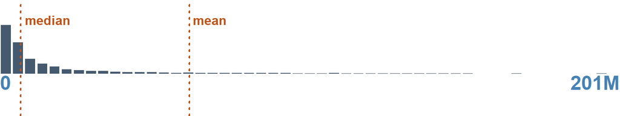

**PREVIEW**:

```
3394000 · 1200000 · 1704000 · 2105000 · 2429000 · 2554000 · 3204000 · 1570000 · 3062000
4444000 · 10609000 · 361000 · 593000 · 1154000 · 1300000 · 1306000 · 1340000 · 1448000 · 1557000
```

**STATS**:

| MIN | Q05 | Q25 | Q50 | MEAN | Q75 | Q95 | MAX |
| --- | --- | --- | --- | --- | --- | --- | --- |
| 53,000 | 1,071,000 | 2,871,150 | 6,698,500 | 61,524,720 | 21,062,450 | 198,305,150 | 9,849,778,000 |

number · measurement

Local current operations, education

`cog_educ_curop`

Local current operations, education (E12, E16, E18, E21). Gap-filled: interpolated between observed years; see also cog_educ_curop_obs, _lin and _locf.

| ROWS | DISTINCT | MISSING/NA | ZERO |
| --- | --- | --- | --- |
| 23,125 | 19,199 (83.0%) | 1,865 (8.1%) | 73 (0.3%) |

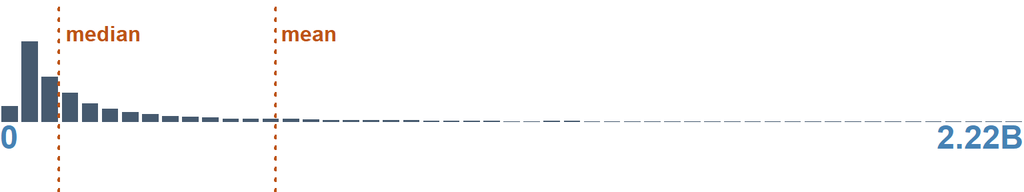

**PREVIEW**:

```
0 · 61701000 · 29542000 · 39329000 · 42024000 · 43309000 · 51438000 · 52576000 · 52933000
54905000 · 55234000 · 63711000 · 68232000 · 74858000 · 75197000 · 76359000 · 81846000 · 85288000
```

**STATS**:

| MIN | Q05 | Q25 | Q50 | MEAN | Q75 | Q95 | MAX |
| --- | --- | --- | --- | --- | --- | --- | --- |
| 0 | 35,198,960 | 65,646,500 | 127,746,800 | 597,497,661 | 320,795,000 | 2,209,055,020 | 81,535,300,000 |

number · measurement

Local public welfare spending

`cog_welfare`

Local public welfare spending (E/J 67, 68, 74, 75, 77, 79). Gap-filled: interpolated between observed years; see also cog_welfare_obs, _lin and _locf.

| ROWS | DISTINCT | MISSING/NA | ZERO |
| --- | --- | --- | --- |
| 23,125 | 14,155 (61.2%) | 1,865 (8.1%) | 1,091 (4.7%) |

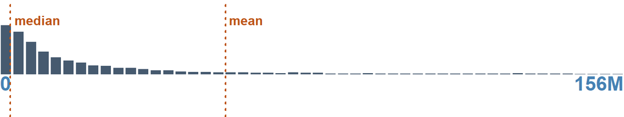

**PREVIEW**:

```
0 · 1000 · 2000 · 12000 · 6000 · 4000 · 3000 · 28000 · 109000 · 5000 · 30000 · 36000 · 74000
10000 · 29000 · 11000 · 22000 · 56000 · 7000 · 44000 · 79000 · 94000 · 90000 · 120000 · 123000
```

**STATS**:

| MIN | Q05 | Q25 | Q50 | MEAN | Q75 | Q95 | MAX |
| --- | --- | --- | --- | --- | --- | --- | --- |
| 0 | 0 | 284,950 | 2,606,600 | 56,574,788 | 16,455,700 | 156,360,550 | 11,407,954,000 |

number · measurement

Local health and hospitals current operations

`cog_health_curop`

Local health and hospitals current operations (E32, E36, E38). Gap-filled: interpolated between observed years; see also cog_health_curop_obs, _lin and _locf.

| ROWS | DISTINCT | MISSING/NA | ZERO |
| --- | --- | --- | --- |
| 23,125 | 18,138 (78.4%) | 1,865 (8.1%) | 89 (0.4%) |

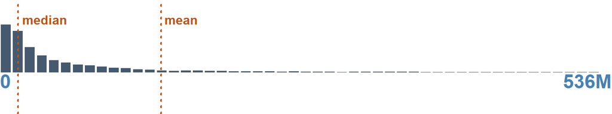

**PREVIEW**:

```
0 · 132000 · 130000 · 558000 · 2000 · 35000 · 82000 · 97000 · 174000 · 413000 · 454000 · 501000
723000 · 819000 · 1706000 · 2880000 · 5078000 · 8310000 · 11225000 · 42326000 · 28000 · 38000
```

**STATS**:

| MIN | Q05 | Q25 | Q50 | MEAN | Q75 | Q95 | MAX |
| --- | --- | --- | --- | --- | --- | --- | --- |
| 0 | 321,390 | 3,454,700 | 15,972,300 | 141,375,663 | 63,066,650 | 526,197,450 | 15,544,367,000 |

number · measurement

Local salaries and wages

`cog_salaries`

Local salaries and wages (Z00; not published for 2022). Gap-filled: interpolated between observed years; see also cog_salaries_obs, _lin and _locf.

| ROWS | DISTINCT | MISSING/NA |
| --- | --- | --- |
| 23,125 | 14,690 (63.5%) | 1,865 (8.1%) |

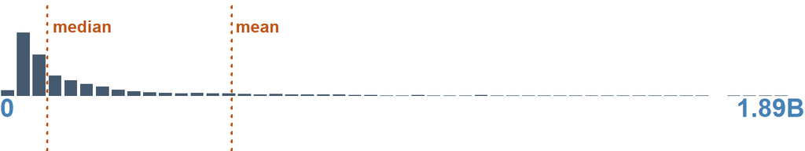

**PREVIEW**:

```
33673000 · 34911000 · 38268000 · 46831000 · 48475000 · 48619000 · 50809000 · 53892000 · 54902000
56597000 · 60130000 · 68026000 · 80207000 · 80314000 · 88016000 · 90879000 · 105319000
```

**STATS**:

| MIN | Q05 | Q25 | Q50 | MEAN | Q75 | Q95 | MAX |
| --- | --- | --- | --- | --- | --- | --- | --- |
| 11,062,000 | 34,155,180 | 60,578,500 | 110,958,000 | 543,374,670 | 283,645,800 | 1,884,888,070 | 60,567,132,000 |

number · measurement

Local intergovernmental revenue from federal government

`cog_fed_igr`